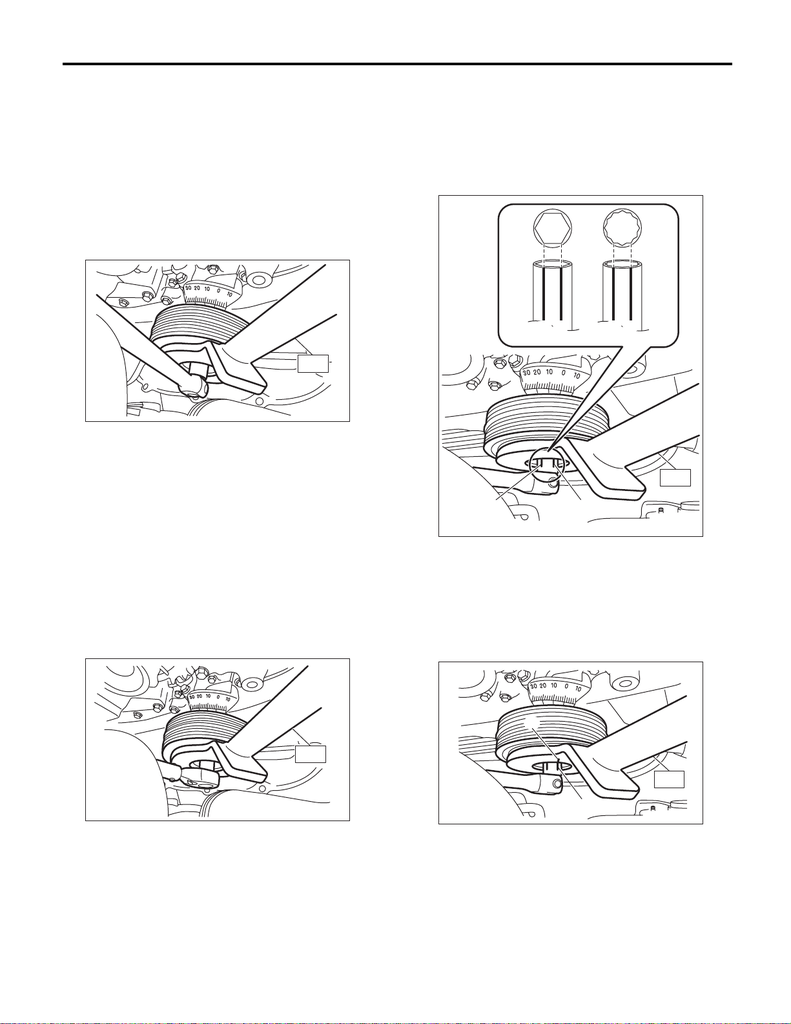

Crank Pulley

13.Crank Pulley

A: REMOVAL

NOTE:

When replacing a single part, perform the work with

the engine assembly installed to body.

1) Remove the V-belts. <Ref. to ME(STI)-41, RE-

MOVAL, V-belt.>

2) Use the ST to lock the crank pulley, and remove

the crank pulley bolt.

ST 499977100 CRANK PULLEY WRENCH

3) Remove the crank pulley.

B: INSTALLATION

1) Clean the crankshaft thread using compressed

air.

2) Install the crank pulley.

3) Apply engine oil to the crank pulley bolt seat and

thread.

4) Tighten the crank pulley bolts.

(1) Use the ST to lock the crank pulley, and

temporarily tighten the crank pulley bolt.

ST 499977100 CRANK PULLEY WRENCH

Tightening torque:

47 N·m (4.8 kgf-m, 34.7 ft-lb)

(2) Draw reference lines (A) and (B) using a

marker to set the socket to the crank pulley bolt

as shown in the figure.

NOTE:

Set the socket onto the crank pulley bolt so that ref-

erence lines (A) and (B) is visible.

ST 499977100 CRANK PULLEY WRENCH

(3) Draw end line (C) on ST using a marker at

the same position as reference line (B) drawn

on the socket in step (2).

ST 499977100 CRANK PULLEY WRENCH

ST

ST

(a) When using 6-point socket

(b) When using 12-point socket

(B)

ST

(A)

(a)

(B)

(A)

(b)

(B)

(A)

(B)

ST

(C)

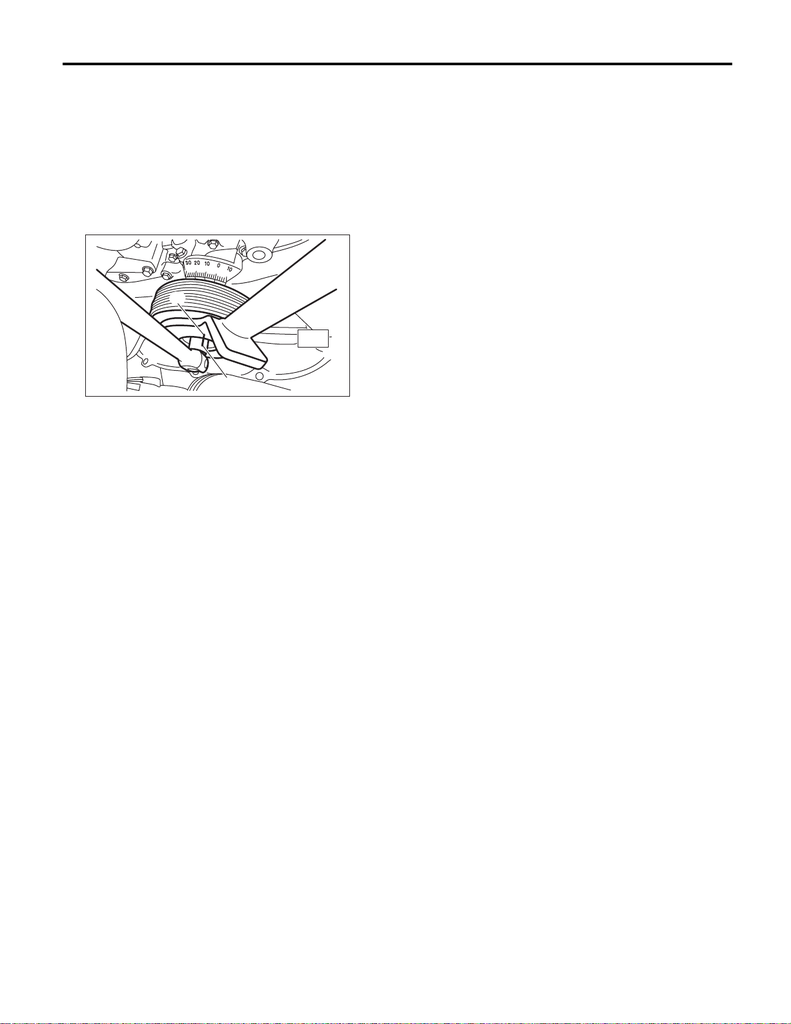

Crank Pulley

(4) Use the ST to lock the crank pulley, and

tighten the crank pulley bolt to the angle where

reference line (A) and end line (C) are aligned.

NOTE:

It should be approx. 60° when reference line (A)

and end line (C) are aligned.

ST 499977100 CRANK PULLEY WRENCH

Tightening angle:

60°

5°

5) Install the V-belts. <Ref. to ME(STI)-41, IN-

STALLATION, V-belt.>

C: INSPECTION

1) Check that the crank pulley has no deformation,

cracks or other damages.

ST

(A)

(C)